# Analyses - Random Forests v1

Joey Hulbert

10/11/2021

# Data

The data used in the below visualizations are described in the Data Wrangle folder.

All tree health categories

```
## # A tibble: 11 x 2
## # Groups:   field.tree.canopy.symptoms [11]
##    field.tree.canopy.symptoms                             n
##    <fct>                                              <int>
##  1 Branch Dieback or 'Flagging'                          19
##  2 Browning Canopy                                       19
##  3 Extra Cone Crop                                        2
##  4 Healthy                                              403
##  5 Multiple Symptoms (please list in Notes)              17
##  6 New Dead Top (red or brown needles still attached)    33
##  7 Old Dead Top (needles already gone)                   83
##  8 Other (please describe in Notes)                       8
##  9 Thinning Canopy                                      118
## 10 Tree is dead                                          37
## 11 Yellowing Canopy                                      10
```

Selected tree health categories

```
## # A tibble: 5 x 2
## # Groups:   field.tree.canopy.symptoms [5]
##   field.tree.canopy.symptoms                             n
##   <fct>                                              <int>
## 1 Healthy                                              403
## 2 New Dead Top (red or brown needles still attached)    33
## 3 Old Dead Top (needles already gone)                   83
## 4 Thinning Canopy                                      118
## 5 Tree is dead                                          37
```

Binary tree health categories

```
## # A tibble: 2 x 2
## # Groups:   field.tree.canopy.symptoms [2]
##   field.tree.canopy.symptoms     n
##   <fct>                      <int>
## 1 Healthy                      403
## 2 Unhealthy                    346
```

# Filter Data

We need to filter the data to only include response and explanatory variables we’re interested in. For example, whether a sound clip was included in the iNat data is not important.

We also need to remove other response variables like “field.percent.canopy.affected….” so it is not used as a predictor for tree health.

> Note it might be interesting to know if the user was an important factor in predicting if the tree is healthy/unhealthy.

We continue to get the below error, but were able to work around it by imputing the data.

> Error in randomForest.default(m, y, …) : Need at least two classes to do classification.

# Impute data

To impute the data we have to remove factors with >53 levels.

The below code lists the number of levels for the variables that are factors.

- The following factors had more than 53 levels
  - “muaggatt_musym”
  - “muaggatt_muname”
  - “component_compname”
  - “component_geomdesc”
  - “component_taxclname”
  - “component_taxsubgrp”

Imputed data table

```
## ntree      OOB      1      2      3      4      5
##   300:  38.43% 12.41% 87.88% 69.88% 73.73% 94.59%
## ntree      OOB      1      2      3      4      5
##   300:  37.54% 10.67% 90.91% 69.88% 73.73% 94.59%
## ntree      OOB      1      2      3      4      5
##   300:  39.32% 12.41% 87.88% 73.49% 75.42% 97.30%
## ntree      OOB      1      2      3      4      5
##   300:  36.94%  8.93% 90.91% 71.08% 76.27% 91.89%
## ntree      OOB      1      2      3      4      5
##   300:  38.13% 12.41% 87.88% 71.08% 71.19% 94.59%
## ntree      OOB      1      2      3      4      5
##   300:  36.80% 10.42% 87.88% 69.88% 70.34% 97.30%
```

# Try creating random forest model from training data

```
##
## Call:
##  randomForest(formula = field.tree.canopy.symptoms ~ ., data = training,      ntree = 2001, importance = TRUE, proximity = TRUE, na.action = na.omit)
##                Type of random forest: classification
##                      Number of trees: 2001
## No. of variables tried at each split: 18
##
##         OOB estimate of  error rate: 40%
## Confusion matrix:
##                                                    Healthy
## Healthy                                                265
## New Dead Top (red or brown needles still attached)      12
## Old Dead Top (needles already gone)                     29
## Thinning Canopy                                         49
## Tree is dead                                            13
##                                                    New Dead Top (red or brown needles still attached)
## Healthy                                                                                             1
## New Dead Top (red or brown needles still attached)                                                  2
## Old Dead Top (needles already gone)                                                                 2
## Thinning Canopy                                                                                     2
## Tree is dead                                                                                        2
##                                                    Old Dead Top (needles already gone)
## Healthy                                                                              9
## New Dead Top (red or brown needles still attached)                                   6
## Old Dead Top (needles already gone)                                                  8
## Thinning Canopy                                                                     14
## Tree is dead                                                                         3
##                                                    Thinning Canopy Tree is dead
## Healthy                                                         17            4
## New Dead Top (red or brown needles still attached)               4            1
## Old Dead Top (needles already gone)                             19            2
## Thinning Canopy                                                 25            6
## Tree is dead                                                     7            3
##                                                    class.error
## Healthy                                              0.1047297
## New Dead Top (red or brown needles still attached)   0.9200000
## Old Dead Top (needles already gone)                  0.8666667
## Thinning Canopy                                      0.7395833
## Tree is dead                                         0.8928571
```

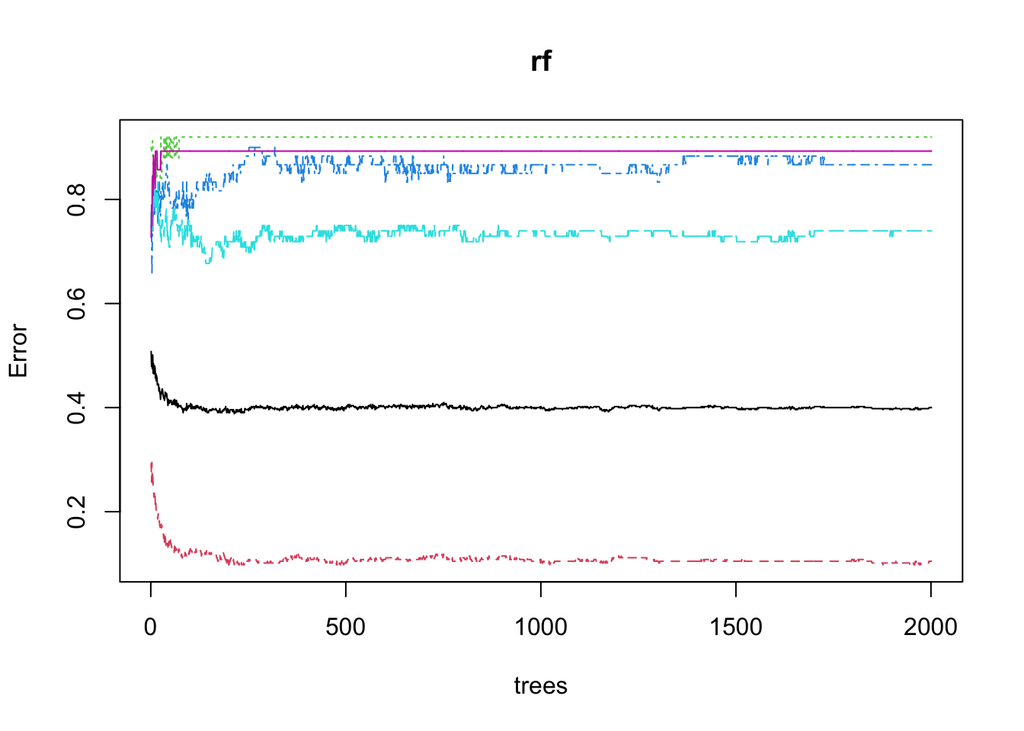

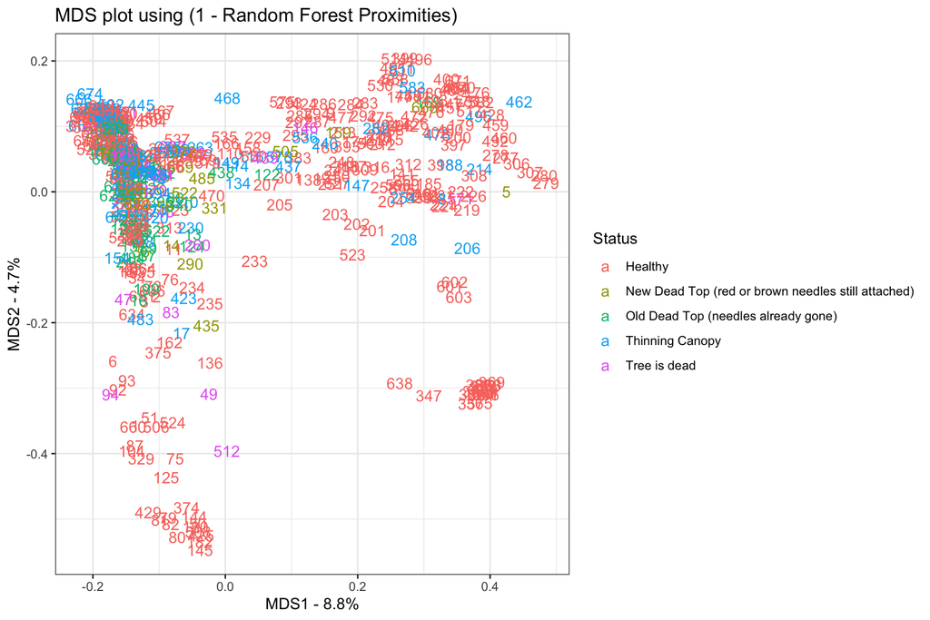

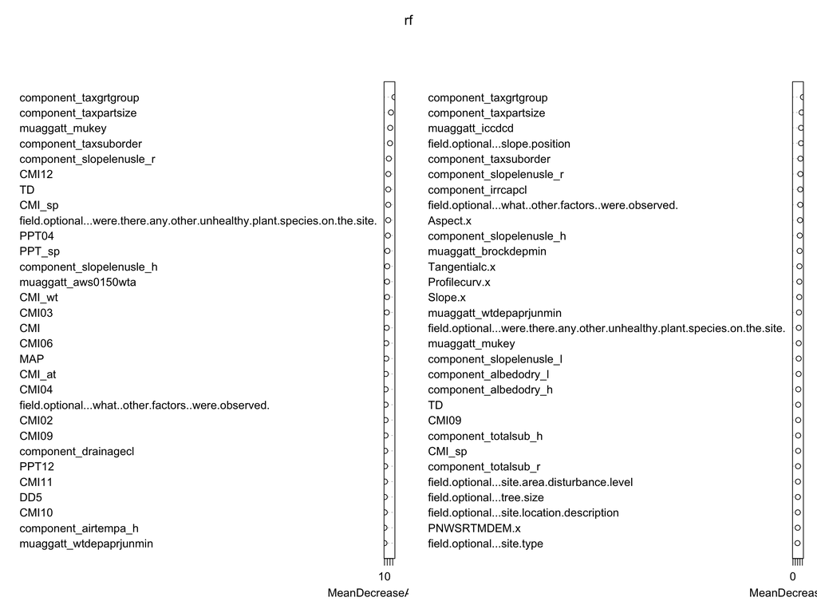

# Troubleshooting

> Error in randomForest.default(m, y, …) : Need at least two classes to do classification.

I may be misunderstanding this error, but I think it is referring to the response variable?

The documentation [here](https://rdrr.io/rforge/randomForest/src/R/randomForest.default.R) describes the error prompt when: if (classRF && !addclass && length(unique(y)) < 2) stop(“Need at least two classes to do classification.”)

Maybe I need to remove columns with more than 53 factors

Removing factors with more than 53 levels didn’t help randomForest, but it did help rfImpute

Wow it actually worked if the data is imputed.